Tholonia - 027-D-Greek_Gods  
The Existential Mechanics of Awareness  
Duncan Stroud  
Published: January 15, 2020  
Updated: Updated: Mar 26, 2026 v8.0.89  
Welkin Wall Publishing  
ISBN-10:  
ISBN-13: 978-1-6780-2532-8  
Copyright ©2020 Duncan Stroud CC BY-NC-SA 4.0

# Appendix D: Greek Gods

###### You wouldn’t want to bump into them in a dark alley

According to Greek mythology, the world began with several primordial beings who begat some gods, who then begat even more gods, and so on. What follows is a brief overview of that begetting and the cosmic drama that typically follows the begetting of gods.

To get a general idea of where these gods lived in the psyches of the flock, here is a concept-cloud based on the gods, the attributes they personified, and where they stand in the hierarchy of divine authority.

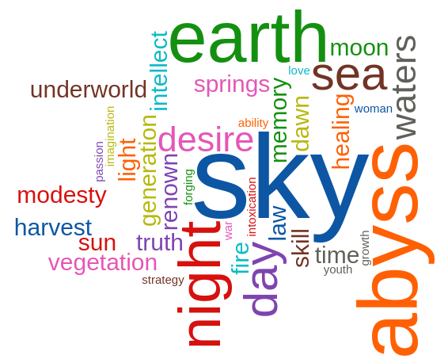

*(The following is a slightly modified transcript reprinted with permission from “The Life Guide” YouTube channel https://www.youtube.com/c/TheLifeGuide, titled “Greek Gods Explained In 12 Minutes”.)*

First came **Chaos**. Then **Gaia**, Earth. From **Gaia** then came **Uranus**, heaven, who together created the **Titans**. And finally, **Eros**, love.

**Uranus** disliked his children and locked them deep within the Earth. **Gaia**, sick of having her children imprisoned, made a great sickle that she gave to her son **Cronus**. **Cronus** hid until Uranus came to lie with his mother, then leaped out and sliced off his father’s genitals, which fell into the sea. **Cronus** proceeded to release his fellow **Titans** from prison, and thus the age of the **Titans** began.

**Cronus** married the **Titan** **Rhea**, who gave birth to most of the major gods. **Cronus**, scared by a prophecy that his children would take his power, imprisoned them as soon as they were born, swallowing them whole. **Rhea** pleaded to **Gaia** for help, who took pity and hid **Zeus** after he was born on Mount Ida in Crete. When **Cronus** came to eat his son, **Rhea** fed him a stone instead, tricking the **Titan**.

**Gaia** raised **Zeus** until he was strong enough to take on his father. The two fought, and upon defeat, **Cronus** was forced to release **Zeus’s** siblings, starting the war between the gods and the **Titans**. The war lasted 12 years until **Zeus** freed the **cyclopes** and the **Hundred-Handed Giants** whom **Cronus** had imprisoned. The **Cyclopes** gifted **Zeus** his famous thunderbolt, **Poseidon** his trident, and **Hades** a Hat of Darkness, tipping the balance of battle.

The **Titans**, defeated, were thrown into **Tartarus**, a prison deep within the underworld and and so started the reign of the gods. **Zeus**, **Poseidon**, and **Hades** decided to share power, drawing lots to decide where they would rule over. **Zeus** got the sky, **Poseidon** the seas, and **Hades** the dead.

**Zeus**, king of the gods, ruled from his throne on Mount Olympus, home of the immortals, often using his symbols of the thunderbolt and eagle to warn or encourage mortals. **Zeus** was responsible for all weather changes, from lightning to snow, depending on his mood. He was also a protector of the home and strangers, meaning being a bad host could land you in deep trouble. **Zeus** married his sister **Hera**, who birthed the gods **Ares** and **Hephaestus**.

**Zeus** was also infamous for his many affairs with other goddesses from which **Athena**, **Hermes**, **Apollo**, **Artemis**, and **Persephone** came. He also engaged in many affairs with mortal women, where he created the god **Dionysus** and many heroes like **Perseus** and **Hercules**, most of whom experienced the wrath of the jealous **Hera**.

**Poseidon**, one of the most powerful gods, ruled the sea, created earthquakes, and was the god of horses, much prized in ancient society. He had a palace on Mount Olympus, but an even more magnificent one under the sea, where he spent most of his time. Sailors would have to pray to **Poseidon** and offer sufficient sacrifice, otherwise risking a painful death at sea. It was very unwise to cross **Poseidon** as he held a grudge and could deal out very harsh punishments.

In the story of **Theseus** and the **Minotaur**, **King Minos** rules over the island of Crete. Every year he sacrificed his best bull to **Poseidon**. One year, he withheld his favorite bull, a huge white animal. **Poseidon** noticed, but instead of punishing **Minos** directly, he decided to target his wife. He made her fall in love with the bull, which eventually led to the birth of the half-man, half-bull creature called the **Minotaur**.

**Hades**, the oldest of the brothers, ruled over the underworld where the spirits of the dead resided. He shared his throne with his wife, **Persephone**, and the two were considered to be gods of fertility. The underworld had several guardians and trials, making it difficult for the dead and near impossible for the living to enter. The gates lay past the deadly river **Styx**. The only way to enter was to get passage from the ferryman, **Charon**. **Charon** required payment, which is why Greek burials included placing coins on the eyes of the deceased. If the soul could not afford to enter, they were fated to wait forever on the shores of the **Styx**.

Past **Charon** lay **Cerberus**, the fabled three-headed dog who guards the underworld gates. Ultimately, the soul will reach the three judges of the underworld, who decide where it should go. They can choose **Elysium**, the Fields of **Asphodel**, or **Tartarus**. **Elysium** is akin to heaven, a peaceful place where the souls of heroes, demigods, and especially good mortals reside. The **Asphodel Meadows** is the place for ordinary folk who did not achieve anything notable in life, good or evil.

**Tartarus** is very similar to Hell and contains not only the **Titans** but also criminals who upset the gods and are tortured for eternity. **Hera**, sister and wife of **Zeus**, and queen of the Gods, was the protector of marriage and women. She was deeply respected in Greek society. She was one of the most vengeful and spiteful gods, punishing women who lay with her husband and any subsequent children. When **Leto** was pregnant with **Apollo** and **Artemis**, Hera stopped her from giving birth. She kept **Io**, another of **Zeus’s** mistresses, as a heifer and had her guarded by the hundred-eyed monster, **Argos**.

A famous tale of her jealous vengeance is the story of **Hercules**. **Hercules** was an illegitimate child of **Zeus**. **Hera** sent serpents to kill the future hero when he was just a child, but the demigod crushed the creatures with his bare hands. She later drove him to madness, making him kill his wife and children, the event that sent him on his 12 labors.

**Athena**, goddess of wisdom and war, the child of **Zeus** and **Metis**, was not born in a conventional way. **Zeus** received an omen that their children would take the throne from him and so swallowed **Metis** while she was pregnant. After this, **Zeus** began to get a terrible headache. He asked a fellow immortal, thought to be **Hephaestus**, to split his head open with an ax. **Athena** was then born from his forehead, jumping out in full battle gear while letting out a war cry.

**Athena** had an affinity for heroics, coming to the aid of heroes like **Perseus** and **Hercules**. Her favorite was **Odysseus**, who she worked hard to keep safe so he could return to his homeland. **Athena** was highly revered in Athens, which was named after her. She competed with **Poseidon** for the city, both of whom attempted to give it the best gift. **Poseidon** struck the ground with his trident, making a water stream rise. **Athena** kicked the Earth and caused the first olive tree to emerge. The gods deemed **Athena** victorious, and the city took her name. **Athena** was also one of the sacred virgin goddesses, and so in her honor, the temple built on the Acropolis in Athens was named the **Parthenon**, which comes from **Parthenos**, meaning “the virgin”.

**Ares** was the bloodthirsty and cruel god of war. Neither god nor mortal particularly liked **Ares**. The warfare he represents is not honorable nor heroic, but rather the primal rage and bloodshed of the battlefield. **Ares** had a relationship with the goddess **Aphrodite** who was married to the god **Hephaestus**. The two would sleep together whenever her husband was away. When **Hephaestus** found out, he made an invisible net, hung it over his bed, and told his wife he was going away. He hid, and as soon as **Ares** and **Aphrodite** got into bed together, they were trapped in the net and unable to move. **Hephaestus** called upon all the gods, inviting them to see the two naked immortals trapped in the net. Laughter burst out everywhere, and it was only due to the intervention of **Poseidon** that they were released.

**Aphrodite** was the goddess of beauty and love, responsible for sexual attraction in both mortal and immortal alike, often using her powers for amusement. Accounts of her birth vary, with her either being born from the genitals of **Uranus** or as another illegitimate child of **Zeus**. **Aphrodite** had a pivotal role in the **Trojan War** when Prince **Paris of Troy** was tasked with giving an apple to the fairest goddess: **Hera**, **Athena**, or **Aphrodite**, each promising him something different in return. **Paris** chose **Aphrodite**, who promised him the most beautiful woman in the world, **Helen**. **Helen** was married to the king of **Sparta**, **Menelaus**. **Aphrodite** put **Helen** under a spell when **Paris** came to visit **Sparta**, making her run away with him. **King Menelaus** and his brother **Agamemnon** raised a massive army to go take **Helen** back from **Troy**, and so started the **Trojan War.**

Goddess of the hunt and the twin sister of **Apollo**, **Artemis** was a deadly archer and an important member of Olympus. She watched over hunters and their prey, ensuring the wilderness was kept in check. **Artemis** is also prized for her virginity and guarded it jealously. The hunter **Actaeon** once stumbled upon her naked as she was bathing. **Artemis** proceeded to change the man into a deer and set his fifty hunting dogs upon him, giving him a painful death for his mistake.

Twin brother of **Artemis**, **Apollo** was a god of many things. He was a god of archery but also light and music, seen with a lyre as much as a bow. **Apollo** is closely linked with prophecy. He was born on Delos and honored the island by setting up an Oracle there. He later traveled to Mount Parnassus and slew the great snake **Pytho**. He created a temple where he had marked the foundations for where the famous **Oracle of Delphi** would reside.

**Hermes** was the messenger of the gods, patron of thieves, and known as a trickster amongst the gods. He often pulled pranks and stole from his fellow divinities. When he came of age, he assumed the role of messenger, taking a golden rod with him as a mark of his authority. He is often seen with a winged helmet and sandals, which he used to fly around and deliver messages.

**Demeter** was the goddess of farming and watcher of the harvest. The one thing she prized more than anything else was her daughter, **Persephone**. It happened that **Hades** was also interested in **Persephone** as he had fallen in love with her. One day, while the girl was picking flowers, he opened up the ground and dragged her down to the underworld. **Demeter** was distraught when she found out and searched for her daughter for nine days and nights until the Sun God **Helios** revealed her captor’s identity. **Demeter** locked herself indoors for an entire year, refusing to come out until **Persephone** was returned. Without the goddess of farming, the world went into famine. To save the world, **Zeus** ordered **Hades** to release **Persephone**. **Hades** had fed the girl the food of the dead, a pomegranate, meaning that she was bound to him. After much discussion, **Zeus** decided that **Hades** could have **Persephone** for three months of the year, and **Demeter** could have her for the other nine months. This explains why the winter months are cold, and the plants die as **Demeter** waits for her daughter to return.

The god of smithing, **Hephaestus**, had a difficult start to life. He was born lame, so his mother **Hera** decided to throw him off Olympus into the sea to drown. He later returned to the home of the gods and was given **Aphrodite** as a wife by **Hera** to reconcile with him. He was a great inventor and fashioned many of the palaces on Olympus. He also fashioned the equipment of many heroes, such as **Achilles**, for whom he created armor and a magnificent shield.

God of wine and parties, **Dionysus** was perhaps the most fun of the Olympians. Frenzied women called **maenads**, and half-goat men called **satyrs** followed him. He had a huge cult following in Greece, where his followers would participate in mass drinking and the orgies his mythological companions were so well known for.

The Greek Gods represent humanity at its best and worst, from the violent and destructive **Ares** to the beautiful and seductive **Aphrodite**. Greek mythology depicts the epic power struggle between parents and children in an endless quest for control over the world. These tales, passed down from generation to generation, show them to be among the most influential deities in human history, with a significant impact to this day.